# Practical Machine Learning - Course Project

Stanislav O. Pogrebnyak

25 Jul 2015

# Background

Using devices such as Jawbone Up, Nike FuelBand, and Fitbit it is now possible to collect a large amount of data about personal activity relatively inexpensively. These type of devices are part of the quantified self movement – a group of enthusiasts who take measurements about themselves regularly to improve their health, to find patterns in their behavior, or because they are tech geeks. One thing that people regularly do is quantify how much of a particular activity they do, but they rarely quantify how well they do it. In this project, your goal will be to use data from accelerometers on the belt, forearm, arm, and dumbell of 6 participants. They were asked to perform barbell lifts correctly and incorrectly in 5 different ways. More information is available from the website here: http://groupware.les.inf.puc-rio.br/har (see the section on the Weight Lifting Exercise Dataset).

# Data

The training data for this project are available here:

https://d396qusza40orc.cloudfront.net/predmachlearn/pml-training.csv

The test data are available here:

https://d396qusza40orc.cloudfront.net/predmachlearn/pml-testing.csv

The data for this project come from this source: http://groupware.les.inf.puc-rio.br/har. If you use the document you create for this class for any purpose please cite them as they have been very generous in allowing their data to be used for this kind of assignment.

# Solution

## Data mining:

First we will import data from csv files with some data cleanups:

```r
train.df <- read.csv("pml-training.csv", sep = ",", header = TRUE, na.strings = c("", "NA", "#DIV/0!"))
test.df <- read.csv("pml-testing.csv", sep = ",", header = TRUE, na.strings = c("", "NA", "#DIV/0!"))
```

## Train:

```r
train.df %>% head(5) %>% kable
```

| X | user_name | raw_timestamp_part_1 | raw_timestamp_part_2 | cvtd_timestamp | new_window | num_window | roll_belt | pitch_belt | yaw_belt | total_accel_belt | kurtosis_roll_belt | kurtosis_picth_belt | kurtosis_yaw_belt | skewness_roll_belt | skewness_roll_belt.1 | skewness_yaw_belt | max_roll_belt | max_picth_belt | max_yaw_belt | min_roll_belt | min_pitch_belt | min_yaw_belt | amplitude_roll_belt | amplitude_pitch_belt | amplitude_yaw_belt | var_total_accel_belt | avg_roll_belt | stddev_roll_belt | var_roll_belt | … |
| --- | --- | --- | --- | --- | --- | --- | --- | --- | --- | --- | --- | --- | --- | --- | --- | --- | --- | --- | --- | --- | --- | --- | --- | --- | --- | --- | --- | --- | --- | --- |
| 1 | carlitos | 1323084231 | 788290 | 05/12/2011 11:23 | no | 11 | 1.41 | 8.07 | -94.4 | 3 | NA | NA | NA | NA | NA | NA | NA | NA | NA | NA | NA | NA | NA | NA | NA | NA | NA | NA | NA | … |
| 2 | carlitos | 1323084231 | 808298 | 05/12/2011 11:23 | no | 11 | 1.41 | 8.07 | -94.4 | 3 | NA | NA | NA | NA | NA | NA | NA | NA | NA | NA | NA | NA | NA | NA | NA | NA | NA | NA | NA | … |
| 3 | carlitos | 1323084231 | 820366 | 05/12/2011 11:23 | no | 11 | 1.42 | 8.07 | -94.4 | 3 | NA | NA | NA | NA | NA | NA | NA | NA | NA | NA | NA | NA | NA | NA | NA | NA | NA | NA | NA | … |
| 4 | carlitos | 1323084232 | 120339 | 05/12/2011 11:23 | no | 12 | 1.48 | 8.05 | -94.4 | 3 | NA | NA | NA | NA | NA | NA | NA | NA | NA | NA | NA | NA | NA | NA | NA | NA | NA | NA | NA | … |
| 5 | carlitos | 1323084232 | 196328 | 05/12/2011 11:23 | no | 12 | 1.48 | 8.07 | -94.4 | 3 | NA | NA | NA | NA | NA | NA | NA | NA | NA | NA | NA | NA | NA | NA | NA | NA | NA | NA | NA | … |

## Test:

```r
test.df %>% head(5) %>% kable
```

| X | user_name | raw_timestamp_part_1 | raw_timestamp_part_2 | cvtd_timestamp | new_window | num_window | roll_belt | pitch_belt | yaw_belt | total_accel_belt | kurtosis_roll_belt | kurtosis_picth_belt | kurtosis_yaw_belt | skewness_roll_belt | skewness_roll_belt.1 | skewness_yaw_belt | max_roll_belt | max_picth_belt | max_yaw_belt | min_roll_belt | min_pitch_belt | min_yaw_belt | amplitude_roll_belt | amplitude_pitch_belt | amplitude_yaw_belt | var_total_accel_belt | avg_roll_belt | stddev_roll_belt | var_roll_belt | … |
| --- | --- | --- | --- | --- | --- | --- | --- | --- | --- | --- | --- | --- | --- | --- | --- | --- | --- | --- | --- | --- | --- | --- | --- | --- | --- | --- | --- | --- | --- | --- |
| 1 | pedro | 1323095002 | 868349 | 05/12/2011 14:23 | no | 74 | 123.00 | 27.00 | -4.75 | 20 | NA | NA | NA | NA | NA | NA | NA | NA | NA | NA | NA | NA | NA | NA | NA | NA | NA | NA | NA | … |
| 2 | jeremy | 1322673067 | 778725 | 30/11/2011 17:11 | no | 431 | 1.02 | 4.87 | -88.90 | 4 | NA | NA | NA | NA | NA | NA | NA | NA | NA | NA | NA | NA | NA | NA | NA | NA | NA | NA | NA | … |
| 3 | jeremy | 1322673075 | 342967 | 30/11/2011 17:11 | no | 439 | 0.87 | 1.82 | -88.50 | 5 | NA | NA | NA | NA | NA | NA | NA | NA | NA | NA | NA | NA | NA | NA | NA | NA | NA | NA | NA | … |
| 4 | adelmo | 1322832789 | 560311 | 02/12/2011 13:33 | no | 194 | 125.00 | -41.60 | 162.00 | 17 | NA | NA | NA | NA | NA | NA | NA | NA | NA | NA | NA | NA | NA | NA | NA | NA | NA | NA | NA | … |
| 5 | eurico | 1322489635 | 814776 | 28/11/2011 14:13 | no | 235 | 1.35 | 3.33 | -88.60 | 3 | NA | NA | NA | NA | NA | NA | NA | NA | NA | NA | NA | NA | NA | NA | NA | NA | NA | NA | NA | … |

Lets remove features with near zero variance:

```r
near.zero.variance  = nearZeroVar(train.df, saveMetrics=TRUE)
nzv.cols = which(near.zero.variance$nzv==TRUE)
train.df.clean = train.df[,-nzv.cols]
train.df.clean %>% head(5) %>% kable
```

| X | user_name | raw_timestamp_part_1 | raw_timestamp_part_2 | cvtd_timestamp | num_window | roll_belt | pitch_belt | yaw_belt | total_accel_belt | kurtosis_roll_belt | kurtosis_picth_belt | skewness_roll_belt | skewness_roll_belt.1 | max_roll_belt | max_picth_belt | max_yaw_belt | min_roll_belt | min_pitch_belt | min_yaw_belt | amplitude_roll_belt | amplitude_pitch_belt | var_total_accel_belt | avg_roll_belt | stddev_roll_belt | var_roll_belt | avg_pitch_belt | stddev_pitch_belt | var_pitch_belt | avg_yaw_belt | … |
| --- | --- | --- | --- | --- | --- | --- | --- | --- | --- | --- | --- | --- | --- | --- | --- | --- | --- | --- | --- | --- | --- | --- | --- | --- | --- | --- | --- | --- | --- | --- |
| 1 | carlitos | 1323084231 | 788290 | 05/12/2011 11:23 | 11 | 1.41 | 8.07 | -94.4 | 3 | NA | NA | NA | NA | NA | NA | NA | NA | NA | NA | NA | NA | NA | NA | NA | NA | NA | NA | NA | NA | … |
| 2 | carlitos | 1323084231 | 808298 | 05/12/2011 11:23 | 11 | 1.41 | 8.07 | -94.4 | 3 | NA | NA | NA | NA | NA | NA | NA | NA | NA | NA | NA | NA | NA | NA | NA | NA | NA | NA | NA | NA | … |
| 3 | carlitos | 1323084231 | 820366 | 05/12/2011 11:23 | 11 | 1.42 | 8.07 | -94.4 | 3 | NA | NA | NA | NA | NA | NA | NA | NA | NA | NA | NA | NA | NA | NA | NA | NA | NA | NA | NA | NA | … |
| 4 | carlitos | 1323084232 | 120339 | 05/12/2011 11:23 | 12 | 1.48 | 8.05 | -94.4 | 3 | NA | NA | NA | NA | NA | NA | NA | NA | NA | NA | NA | NA | NA | NA | NA | NA | NA | NA | NA | NA | … |
| 5 | carlitos | 1323084232 | 196328 | 05/12/2011 11:23 | 12 | 1.48 | 8.07 | -94.4 | 3 | NA | NA | NA | NA | NA | NA | NA | NA | NA | NA | NA | NA | NA | NA | NA | NA | NA | NA | NA | NA | … |

Also we need to remove all the columns with NAs values:

```r
NAs = apply(train.df.clean, 2, function(x) { sum(is.na(x)) })
cols.with.data = names(NAs[NAs == 0])
predictors = grep("(belt|arm|dumbbell)", cols.with.data, value=T)
train.df.clean = cbind(train.df.clean[,c(predictors, "classe")])
```

Features(predictors) relationships with classes using featurePlot from caret:

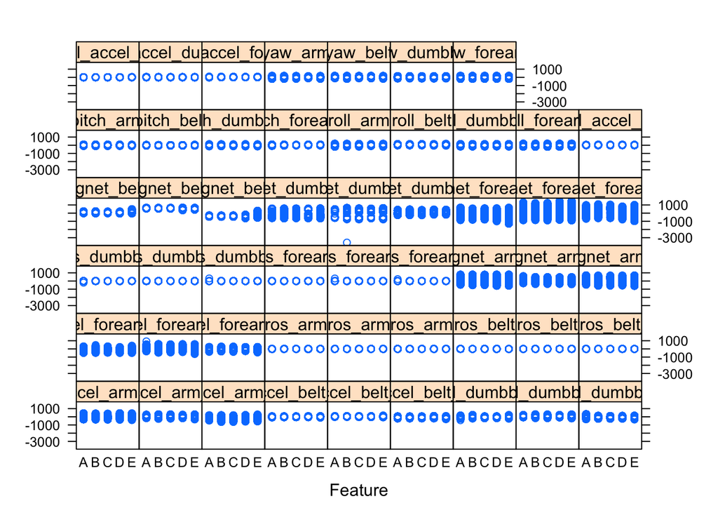

```r
featurePlot(train.df.clean[,1:52], train.df.clean$classe, "strip")
```

Correlations matrix between features itself:

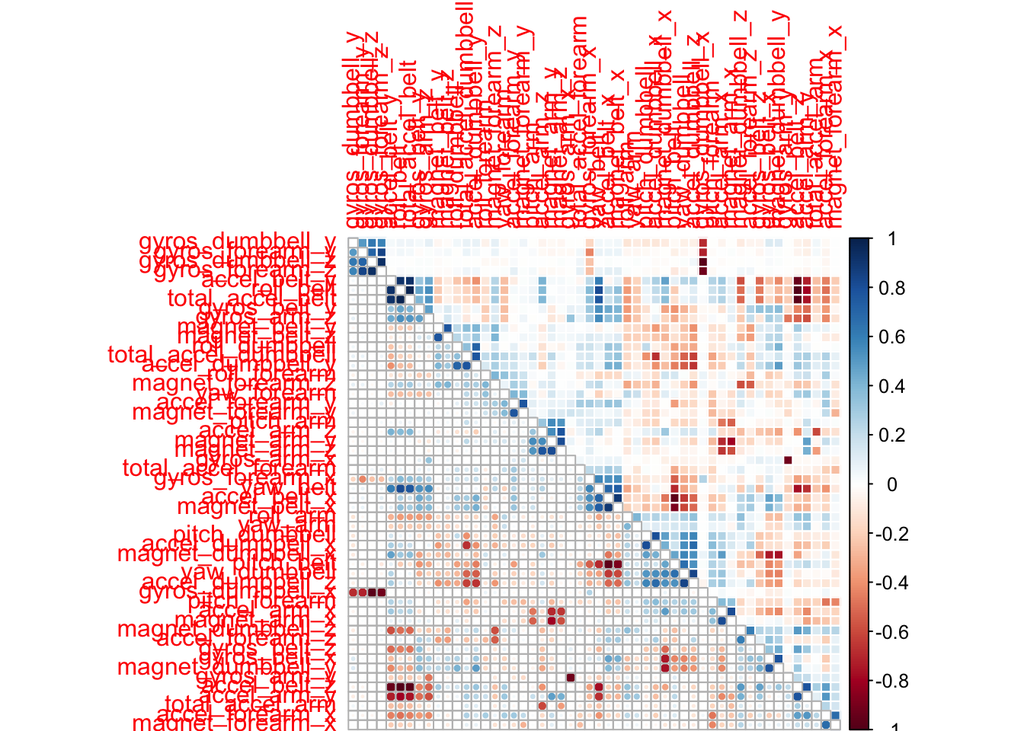

```r
corrplot.mixed(cor(train.df.clean[,1:52]), lower="circle", upper="color",
               tl.pos="lt", diag="n", order="hclust", hclust.method="complete")
```

## ML Model

After that we can train the model. Splitting the training set in to 60/40:

```r
inTrain  = createDataPartition(train.df.clean$classe, p = 0.6, list = FALSE)
train.final = train.df.clean[inTrain,]
test.final = train.df.clean[-inTrain,]
```

## Creating model fit using caret package

```r
trc = trainControl(method = "cv", number = 4, allowParallel=T)
random.Forest.fit = train(classe ~ ., data = train.final, method = "rf", trControl = trc)
```

## Model validation and confusion matrix

```r
random.Forest.prediction = predict(random.Forest.fit, test.final)
prediction.results = confusionMatrix(random.Forest.prediction, test.final$classe)
prediction.results
```

```
## Confusion Matrix and Statistics
##
##           Reference
## Prediction    A    B    C    D    E
##          A 2231   11    0    0    0
##          B    1 1502   15    0    0
##          C    0    5 1351   22    3
##          D    0    0    2 1264    4
##          E    0    0    0    0 1435
##
## Overall Statistics
##
##                Accuracy : 0.992
##                  95% CI : (0.9897, 0.9938)
##     No Information Rate : 0.2845
##     P-Value [Acc > NIR] : < 2.2e-16
##
##                   Kappa : 0.9898
##  Mcnemar's Test P-Value : NA
##
## Statistics by Class:
##
##                      Class: A Class: B Class: C Class: D Class: E
## Sensitivity            0.9996   0.9895   0.9876   0.9829   0.9951
## Specificity            0.9980   0.9975   0.9954   0.9991   1.0000
## Pos Pred Value         0.9951   0.9895   0.9783   0.9953   1.0000
## Neg Pred Value         0.9998   0.9975   0.9974   0.9967   0.9989
## Prevalence             0.2845   0.1935   0.1744   0.1639   0.1838
## Detection Rate         0.2843   0.1914   0.1722   0.1611   0.1829
## Detection Prevalence   0.2858   0.1935   0.1760   0.1619   0.1829
## Balanced Accuracy      0.9988   0.9935   0.9915   0.9910   0.9976
```

## Prediction of the answers

```r
test.df.clean = test.df[, names(train.final)[-53]]
project.answers = predict(random.Forest.fit, test.df.clean)
test.df.clean$classe <- project.answers
test.df.clean$classe %>% head(5) %>% kable
```

[output not shown]

Final output for submition:

```r
pml_write_files = function(x){
        n = length(x)
        for(i in 1:n){
                filename = paste0("problem_id_",i,".txt")
                write.table(x[i],file=filename,quote=FALSE,row.names=FALSE,col.names=FALSE)
        }
}
pml_write_files(project.answers)
```